Serie de apuntes · Diagnóstico Organizacional · Guía de apoyo

# Guía rápida de JASP para diagnóstico organizacional

Diagnóstico Organizacional (MCG9003), Magíster en Control de Gestión, FAE UDP · 2º semestre 2026  
Apunte 0 · Guía de apoyo para las sesiones 3, 5 y 6 (instalar JASP antes de la sesión 5 del viernes 20-11-2026)  
Prof. [René Gempp](https://www.gempp.cl)  
[Página del curso](https://gempp.cl/teaching/do_mcg/)

Esta guía cubre lo mínimo necesario para analizar una encuesta organizacional en JASP: instalar el programa, importar los datos, revisar los ítems, examinar correlaciones, ejecutar un análisis factorial exploratorio, estimar la fiabilidad, construir puntuaciones de escala y exportar los resultados. Al terminarla, el lector podrá replicar la demostración de la sesión 5 y resolver los controles 5 y 6 con sus propios datos.

## 1. Qué es JASP y cómo instalarlo

JASP es un programa de análisis estadístico gratuito y de código abierto, desarrollado en la Universidad de Ámsterdam, con una interfaz de menús que muestra los resultados en el momento en que se seleccionan las variables (JASP Team, 2025). Para el curso tiene tres ventajas: no exige programar, incluye en un solo lugar los análisis que se usan en el diagnóstico de encuestas (descriptivos, correlaciones, análisis factorial, fiabilidad, comparación de grupos) y produce tablas en formato de publicación que se copian directamente a un informe.

Se descarga desde jasp-stats.org (botón "Download") para Windows, macOS y Linux. Conviene instalar la versión estable vigente, no las versiones de prueba. En Windows, si la instalación corporativa bloquea el instalador, existe una versión portable (archivo comprimido) que no requiere permisos de administrador. Al abrir JASP por primera vez, en el menú de la esquina superior izquierda (icono de tres líneas) se puede cambiar el idioma de la interfaz en "Preferences", "Interface"; esta guía usa los nombres de menú en inglés, que son los que aparecen en la demostración y en la mayoría de los tutoriales. Los nombres corresponden a las versiones recientes del programa y pueden variar levemente entre versiones.

Antes de la sesión 5

Instalar JASP, abrirlo una vez para verificar que funciona y descargar de Canvas los archivos de la demostración (Sesion5_Demostración) y del ejercicio (Sesion_5_ejercicio). Instalarlo durante la sesión consume el tiempo del control.

Las capturas de esta guía provienen de las demostraciones del curso en años anteriores; la interfaz de la versión actual de JASP puede diferir en detalles menores (iconos, orden de las opciones), pero los nombres de los análisis y de las tablas se mantienen.

## 2. Preparar e importar los datos

JASP abre archivos CSV (valores separados por comas), archivos de SPSS (.sav), de hoja de cálculo (.ods y, en versiones recientes, .xlsx) y sus propios archivos .jasp, que guardan datos, análisis y resultados juntos. El formato más seguro es CSV. Antes de importar, la base debe cumplir cuatro condiciones.

- **Una fila por persona y una columna por variable.** La primera fila contiene los nombres de las variables, sin tildes ni espacios (por ejemplo, `P01`, `Area`, `Antiguedad`). Un archivo en formato largo (una fila por respuesta a cada ítem, como la hoja BASE de algunos exportes de plataformas) debe reorganizarse antes.
- **Ítems codificados como números.** Las respuestas "totalmente en desacuerdo" a "totalmente de acuerdo" se registran de 1 a 5, no como texto. Si la plataforma exportó etiquetas, se recodifican en la hoja de cálculo antes de importar.
- **Datos perdidos vacíos.** Las celdas sin respuesta quedan en blanco; no se usan 0, 99 ni "NA" salvo que se declare después en JASP (menú de preferencias, "Data", "Missing value list").
- **Separador decimal.** Si la hoja de cálculo está configurada en español (coma decimal y punto y coma como separador de columnas), al exportar a CSV conviene elegir el separador punto y coma o convertir la configuración; JASP detecta el separador en la mayoría de los casos, pero conviene revisar la vista de datos después de importar.

Para importar: menú principal, "Open", "Computer", "Browse", y seleccionar el archivo. Los datos aparecen en el panel izquierdo. En la cabecera de cada columna, un icono indica el tipo de variable: regla (escala, numérica), barras ordenadas (ordinal) o etiqueta (nominal). Los ítems de escala pueden quedar como numéricos o como ordinales; las variables de clasificación (área, género, antigüedad en tramos) deben quedar como nominales u ordinales. El tipo se cambia pulsando el icono.

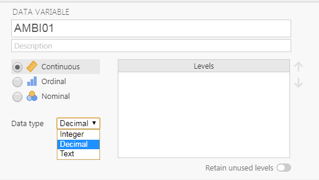

Figura 1. Cuadro de definición de una variable en JASP: tipo de variable (continua, ordinal, nominal) y tipo de dato. Captura de la demostración del curso (2025).

Ejemplo · base TechNova

Encuesta_TechNova_Datos.xlsx tiene 128 casos y 27 variables: identificador, variables de clasificación (área, antigüedad, nivel, género), ítems de 1 a 5 agrupados por dimensión, un ítem de intención de salida, un ítem eNPS de 0 a 10 y dos preguntas abiertas. Las preguntas abiertas no se analizan en JASP (sesión 4); conviene exportar a CSV solo las columnas numéricas y de clasificación, o dejarlas como nominales y no seleccionarlas.

## 3. Descriptivos de ítems

Pestaña "Descriptives", opción "Descriptive Statistics". Se arrastran los ítems al cuadro "Variables". En "Statistics" se marcan media, mediana, desviación estándar, mínimo, máximo, asimetría (skewness) y curtosis; en la sección de tablas, "Frequency tables" muestra cuántas personas eligieron cada alternativa, y en "Plots", "Distribution plots" produce el gráfico de barras de cada ítem. Para comparar por grupo, se arrastra la variable de clasificación al cuadro "Split".

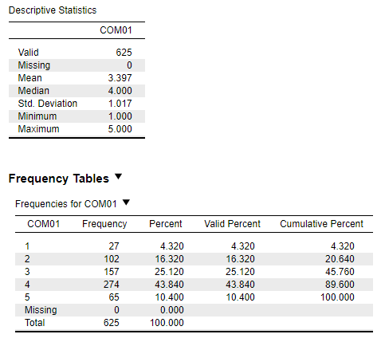

Figura 2. Salida de "Descriptive Statistics" para un ítem de 1 a 5: estadísticos (n válido, perdidos, media, mediana, desviación estándar, mínimo y máximo) y tabla de frecuencias. Datos de la demostración de la sesión 5.

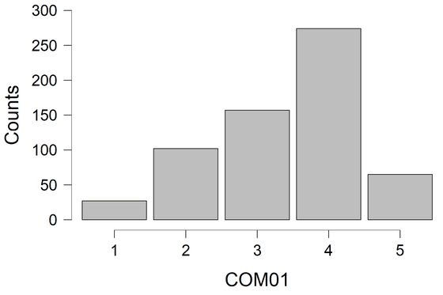

Figura 3. "Distribution plot" del mismo ítem: se usan las cinco alternativas, con concentración en 3 y 4. Un ítem con 90% de respuestas en un extremo discriminaría poco.

Qué se revisa en este paso (sesión 5, paso 1): que se usen todas las alternativas de respuesta, que no haya valores fuera de rango (un 6 en una escala de 1 a 5 es un error de codificación), que los datos perdidos por ítem no superen el 5%, y la forma de la distribución (un ítem con 90% de respuestas en el extremo superior discrimina poco). Los ítems inversos se recodifican antes de seguir: en la vista de datos, pulsar el signo "+" a la derecha de la última columna para crear una columna calculada, elegir el modo R o el modo de fórmula arrastrable y escribir, para una escala de 1 a 5, `6 - P07`.

## 4. Correlaciones

Pestaña "Regression", opción "Correlation". Se arrastran los ítems de una o varias escalas a "Variables". Por defecto se calcula el coeficiente de Pearson; para ítems ordinales con pocas categorías puede añadirse el de Spearman. "Report significance" y "Flag significant correlations" se pueden desmarcar: con encuestas censales de cientos de casos casi todo es significativo y lo que interesa es la magnitud. En "Plots", "Heatmap" produce un mapa de calor que facilita ver los bloques de ítems que correlacionan entre sí.

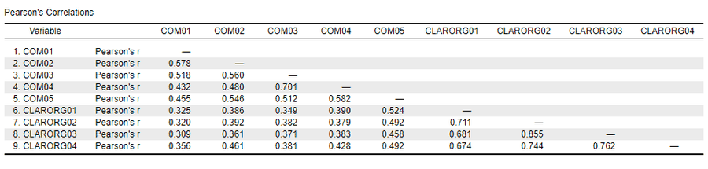

Figura 4. Matriz de correlaciones de Pearson entre los ítems de dos escalas (COM01 a COM05 y CLARORG01 a CLARORG04). Las correlaciones dentro de cada bloque son mayores que entre bloques, el patrón esperado cuando las escalas miden constructos distintos.

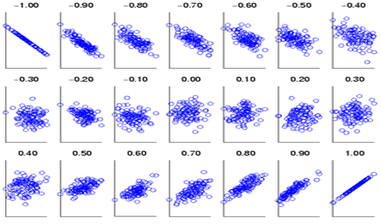

Figura 5. Cómo se ve un diagrama de dispersión para cada magnitud del coeficiente de correlación, de −1,00 a +1,00. En encuestas organizacionales, las correlaciones entre ítems de una misma escala suelen estar entre .30 y .70.

Qué se revisa (paso 2a): que los ítems de una misma escala correlacionen positivamente entre sí (como regla práctica, por sobre .15) y más entre ellos que con los ítems de otras escalas. Un ítem con correlaciones cercanas a cero con el resto de su escala, o negativas, suele ser un ítem inverso sin recodificar o un ítem que mide otra cosa.

## 5. Análisis factorial exploratorio

Pestaña "Factor", opción "Exploratory Factor Analysis". Se arrastran los ítems a "Variables". Las opciones relevantes para el curso son las siguientes.

- **Número de factores.** "Based on parallel analysis" es la opción por defecto y la recomendada; "Manual" permite fijar el número de factores que el plan de dimensiones prevé, para comparar la solución esperada con la encontrada.
- **Método de estimación.** Mínimos residuales ("minimum residual") o máxima verosimilitud; para ítems de 1 a 5 ambos funcionan.
- **Rotación.** Oblicua ("oblimin" o "promax"), porque las dimensiones de clima correlacionan entre sí. La rotación ortogonal (varimax) supone factores independientes, lo que rara vez ocurre en encuestas organizacionales.
- **Tabla de cargas.** En "Output options", fijar "Display loadings above" en .30 para que la tabla oculte las cargas menores y la estructura se lea de un vistazo; marcar "Order loadings by size".
- **Gráficos.** "Scree plot" muestra los autovalores y la línea del análisis paralelo; "Path diagram" dibuja la solución.

Qué se revisa (paso 2b): cuántos factores sugiere el análisis paralelo frente a cuántas dimensiones previó el cuestionario; qué ítems cargan por sobre .30 en el factor esperado; qué ítems tienen cargas cruzadas (por sobre .30 en dos factores) o no cargan en ninguno. La tabla de correlaciones entre factores indica cuánto se solapan las dimensiones: correlaciones por sobre .70 sugieren que dos dimensiones miden casi lo mismo.

Idea clave

El análisis factorial no decide por el analista. La solución estadística se compara con el plan de dimensiones y con el contenido de los ítems; un ítem que carga en el factor "equivocado" puede estar mal escrito, mal asignado o revelando una dimensión real que el plan no previó.

## 6. Fiabilidad: alfa y omega

Pestaña "Reliability", opción "Unidimensional Reliability" (si la pestaña no aparece, se activa en el menú "+" de la derecha, módulo "Reliability"). Se arrastran los ítems de una sola escala a "Variables"; el análisis se repite para cada escala. En "Scale Statistics" se marcan "McDonald's ω" y "Cronbach's α"; en "Individual Item Statistics", "If item dropped" para ambos coeficientes y "Item-rest correlation". Si la escala tiene ítems inversos que no se recodificaron antes, se declaran en "Reverse-Scaled Items".

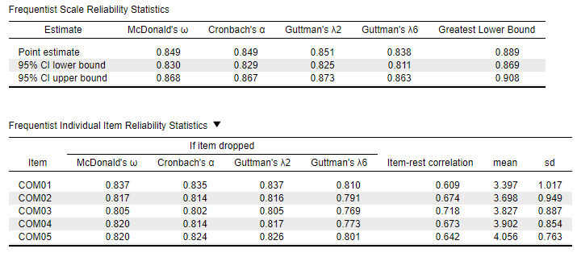

Figura 6. Salida de "Unidimensional Reliability": coeficientes de escala (omega de McDonald, alfa de Cronbach, lambda de Guttman) con intervalos de confianza, y estadísticos por ítem (coeficiente si se elimina el ítem, correlación ítem-resto, media y desviación estándar).

Qué se revisa (paso 3): que alfa y omega superen el umbral orientativo de .70 para uso descriptivo y grupal; que la correlación ítem-resto de cada ítem sea positiva y, como regla práctica, por sobre .30; y qué pasa con el coeficiente si se elimina cada ítem. Un ítem cuya eliminación sube el coeficiente de manera apreciable y que tiene correlación ítem-resto baja es candidato a eliminar o reescribir. Con escalas de tres o cuatro ítems, los coeficientes son más bajos por construcción y conviene interpretarlos con cautela.

## 7. Puntuaciones de escala y análisis por subgrupos

Una vez decidida la composición de cada escala, se construye la puntuación como promedio de sus ítems: en la vista de datos, "+" para crear una columna calculada, nombre de la escala (por ejemplo, `Claridad`), y en el modo R la fórmula `rowMeans(cbind(P01, P02, P03, P04), na.rm = TRUE)`, o en el modo de fórmula arrastrable, la función "mean" con los ítems. El promedio conserva la métrica original (1 a 5), lo que facilita la lectura, y tolera un dato perdido ocasional; la suma no. Se recomienda calcular la puntuación solo para quienes respondieron al menos dos tercios de los ítems de la escala.

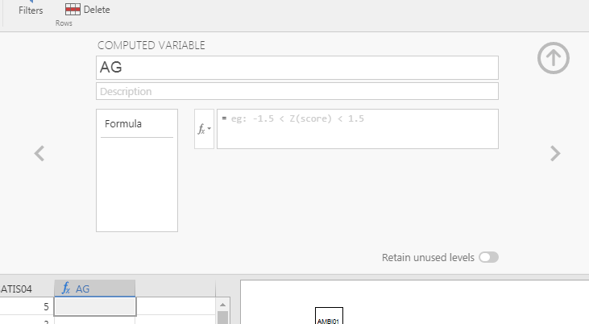

Con las puntuaciones construidas, "Descriptives" con la variable de clasificación en "Split" produce las medias por área, antigüedad o nivel (sesión 6). Para comparar grupos: "T-Tests", "Independent Samples T-Test" para dos grupos; "ANOVA", "ANOVA" para tres o más, con la escala en "Dependent Variable" y la variable de clasificación en "Fixed Factors", marcando en "Post Hoc Tests" la comparación por pares y en "Descriptives plots" el gráfico de medias. Para las relaciones entre escalas y con la intención de salida o el eNPS, "Regression", "Correlation" con las puntuaciones. El eNPS se calcula fuera de JASP o con una columna calculada que clasifique 9 y 10 como promotores, 0 a 6 como detractores, y luego con una tabla de frecuencias.

Antes de comparar unidades

Una media por unidad con menos de cinco respuestas no se reporta: rompe el anonimato y es inestable. Las diferencias entre unidades se leen junto con la fiabilidad de la escala (sesión 5) y con la tasa de respuesta por unidad.

## 8. Exportar y guardar

"Save as" guarda un archivo .jasp con datos, análisis y resultados; es el formato que se adjunta en los controles. Cada tabla y gráfico tiene, al pasar el cursor por su título, un menú desplegable con "Copy" (para pegar en Word o PowerPoint), "Copy LaTeX" y, en los gráficos, "Save Image As". El panel completo de resultados se exporta con "Export Results" en formato HTML o PDF. Las tablas copiadas conservan el formato APA, de modo que no es necesario reconstruirlas.

## 9. Problemas frecuentes

| Síntoma | Causa probable | Solución |
| --- | --- | --- |
| Los ítems aparecen como nominales y no se pueden usar en correlaciones | Columnas con texto, comas decimales o celdas con "NA" | Limpiar la hoja de cálculo, recodificar a números y reimportar; o cambiar el tipo pulsando el icono de la cabecera |
| Una sola columna con todo el contenido | Separador del CSV no detectado | Exportar de nuevo con separador coma y punto decimal, o abrir el .xlsx directamente |
| Alfa negativo o muy bajo | Ítem inverso sin recodificar | Declararlo en "Reverse-Scaled Items" o crear la columna recodificada |
| El análisis factorial no corre o advierte sobre la matriz | Demasiados ítems para pocos casos, ítems sin varianza o duplicados | Eliminar ítems constantes o idénticos; analizar por bloques de dimensiones |
| Resultados que cambian al reabrir el archivo | Se guardó el CSV y no el .jasp | Guardar siempre como .jasp; el CSV solo contiene los datos |
| No aparece la pestaña "Reliability" | Módulo no activado | Menú "+" a la derecha de las pestañas y marcar "Reliability" |

Referencias

DeVellis, R. F., & Thorpe, C. T. (2022). *Scale development: Theory and applications* (5th ed.). Sage.

Goss-Sampson, M. A. (2022). *Statistical analysis in JASP: A guide for students*. JASP. https://jasp-stats.org/jasp-materials/

JASP Team. (2025). *JASP* (Version 0.95) [Computer software]. https://jasp-stats.org/

Nunnally, J. C., & Bernstein, I. H. (1994). *Psychometric theory* (3rd ed.). McGraw-Hill.